# Statistical Rethinking: Chapter 8

Simon Thornewill von Essen

2024-06-24

In this file, we’ll be going through some examples where we may use interactions in regression analysis.

# Example 1: Africa GDP vs RoW

Let’s import the data and do some basic feature engineering.

```r
data(rugged)
d = rugged

#make log version of outcome
d$log_gdp = log(d$rgdppc_2000)

#extract countries with GDP data
dd = d[complete.cases(d$rgdppc_2000),]

#rescale variables
dd$log_gdp_std = dd$log_gdp/ mean(dd$log_gdp)
dd$rugged_std = dd$rugged/ max(dd$rugged)

# Add Africa Index Var
dd$cid = ifelse(dd$cont_africa==1, 1, 2)
```

First, let’s build a basic model and put some priors on it:

```r
m8.1 = quap(
  alist(
    log_gdp_std ~ dnorm(mu, sigma),
    mu <- a + b*(rugged_std - 0.215),
    a ~ dnorm(1, 0.1),
    b ~ dnorm(0, 0.3),
    sigma ~ dexp(1)
  ),
  data=dd
)
```

Now, let’s take a look at prior predictive distribution.

```r
set.seed(1)
prior = extract.prior(m8.1)
```

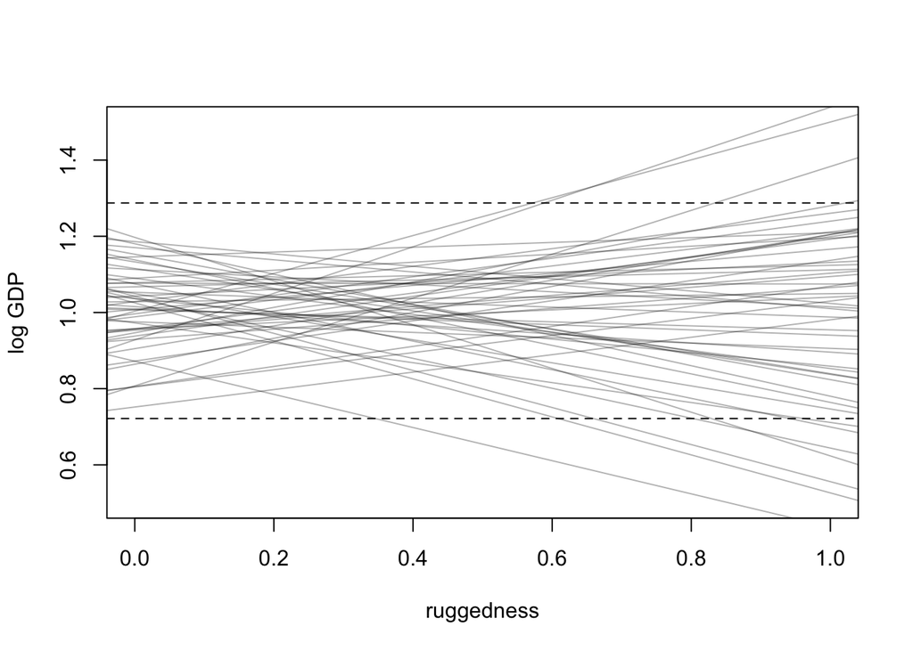

```r
mu = link(m8.1, post=prior,
     data=data.frame(rugged_std=seq(from=-0.1, to=1.1, length.out=30)))

# Plot the dimensions
plot(NULL, xlim=c(0, 1), ylim=c(0.5, 1.5),
     xlab="ruggedness", ylab="log GDP")
abline(h=min(dd$log_gdp_std), lty=2)
abline(h=max(dd$log_gdp_std), lty=2)
for(i in 1:50) lines(seq(from=-0.1, to=1.1, length.out=30),
                     mu[i,],
                     col=col.alpha("black", 0.3))
```

Here, we’re taking 50 random lines and plotting them against ruggedness. Note that we get the expectation by passing both the prior to the link function but also passing the data that we want to plot over.

What would happen if we wanted to get the actual results?

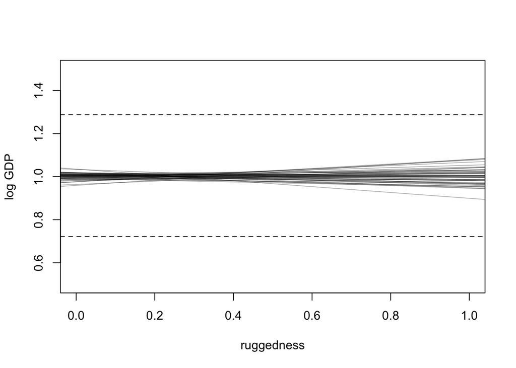

```r
post = extract.samples(m8.1)

mu = link(m8.1, post=post,
     data=data.frame(rugged_std=seq(from=-0.1, to=1.1, length.out=30)))

# Plot the dimensions
plot(NULL, xlim=c(0, 1), ylim=c(0.5, 1.5),
     xlab="ruggedness", ylab="log GDP")
abline(h=min(dd$log_gdp_std), lty=2)
abline(h=max(dd$log_gdp_std), lty=2)
for(i in 1:50) lines(seq(from=-0.1, to=1.1, length.out=30),
                     mu[i,],
                     col=col.alpha("black", 0.3))
```

Now, to add the interaction, we need to add the `cid` to both `alpha` and `beta`.

```r
m8.2 = quap(
  alist(
    log_gdp_std ~ dnorm(mu, sigma),
    mu <- a[cid] + b*(rugged_std - 0.215),
    a[cid] ~ dnorm(1, 0.1),
    b ~ dnorm(0, 0.3),
    sigma ~ dexp(1)
  ),
  data=dd
)

m8.3 = quap(
  alist(
    log_gdp_std ~ dnorm(mu, sigma),
    mu <- a[cid] + b[cid]*(rugged_std - 0.215),
    a[cid] ~ dnorm(1, 0.1),
    b[cid] ~ dnorm(0, 0.3),
    sigma ~ dexp(1)
  ),
  data=dd
)
```

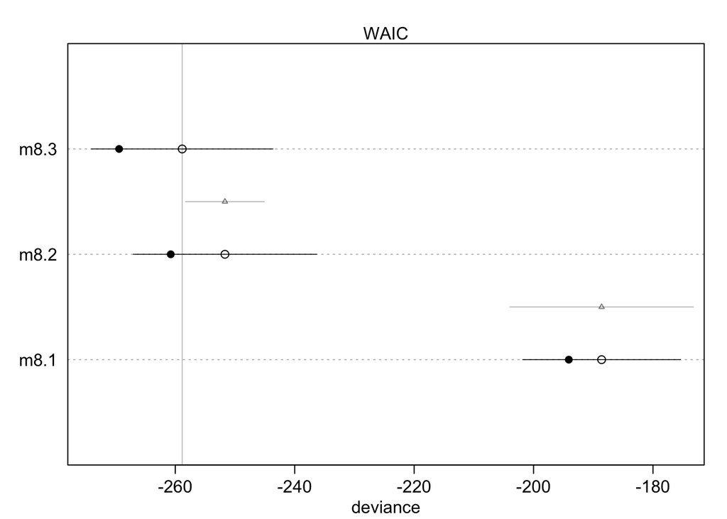

```r
plot(compare(m8.1, m8.2, m8.3))
```

We can see that among these models, `m8.3` performs the best. Even if it’s the most flexible model. We can see though that `m8.2` performs similarly and that `m8.1` way under-fits relative to these two.

Let’s try and plot the outcome of `m8.3`

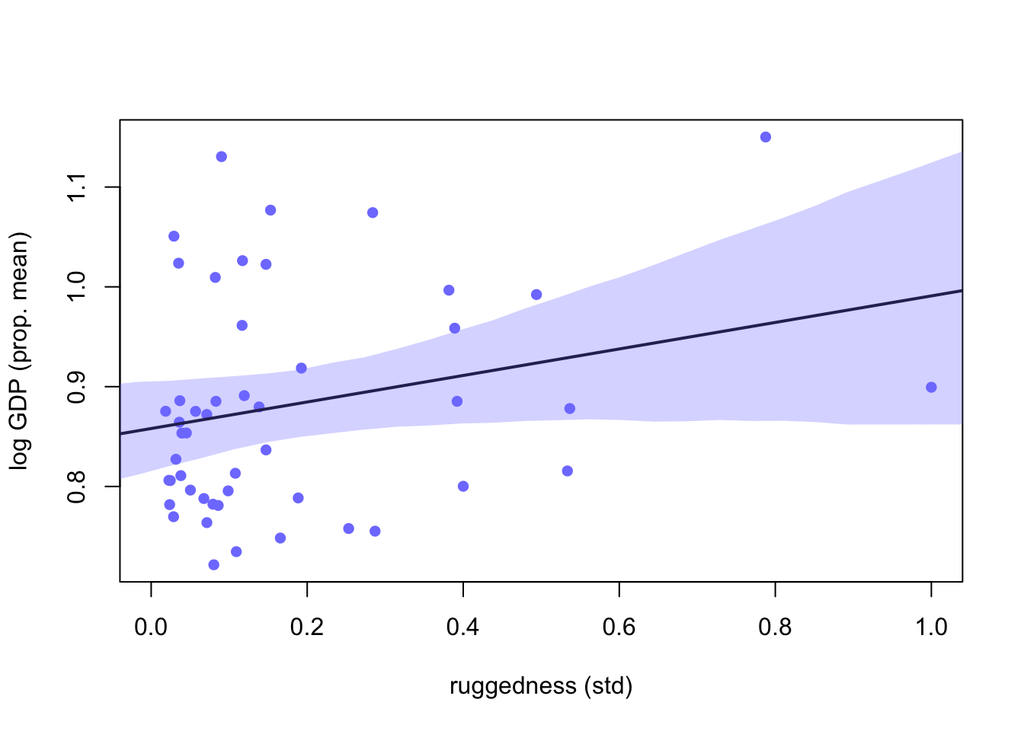

```r
d.A1 = dd[dd$cid==1, ]
rugged_seq=seq(from=-0.1, to=1.1, length.out=30)
mu = link(m8.3, data=data.frame(cid=1,
                                rugged_std=rugged_seq))
mu_mean = apply(mu, 2, mean)
mu_ci = apply(mu, 2, PI, prob=0.97)

plot(d.A1$rugged_std, d.A1$log_gdp_std,
     xlab="ruggedness (std)", ylab="log GDP (prop. mean)",
     xlim=c(0, 1),
     pch=16, col=rangi2)
lines(rugged_seq, mu_mean, lwd=2)
shade(mu_ci, rugged_seq, col=col.alpha(rangi2, 0.3))
```

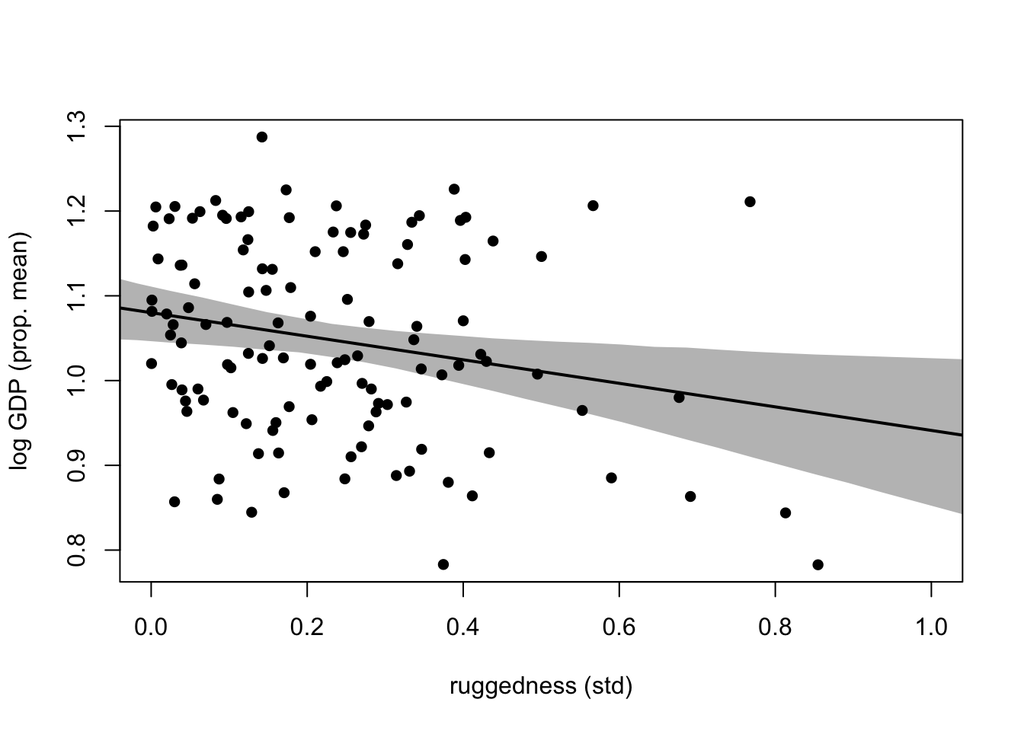

```r
d.A2 = dd[dd$cid==2, ]
rugged_seq=seq(from=-0.1, to=1.1, length.out=30)
mu = link(m8.3, data=data.frame(cid=2,
                                rugged_std=rugged_seq))
mu_mean = apply(mu, 2, mean)
mu_ci = apply(mu, 2, PI, prob=0.97)

plot(d.A2$rugged_std, d.A2$log_gdp_std,
     xlab="ruggedness (std)", ylab="log GDP (prop. mean)",
     xlim=c(0, 1),
     pch=16)
lines(rugged_seq, mu_mean, lwd=2)
shade(mu_ci, rugged_seq, col=col.alpha('black', 0.3))
```

We can see the interaction fully at work here. Furthermore, we can quickly plot how ruggedness changes the expected difference in log GDP.

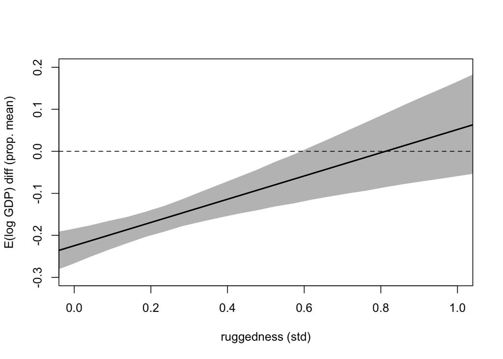

```r
rugged_seq=seq(from=-0.2, to=1.2, length.out=30)

muA = link(m8.3, dat=data.frame(cid=1, rugged_std=rugged_seq))
muN = link(m8.3, dat=data.frame(cid=2, rugged_std=rugged_seq))
delta = muA - muN
delta_mean = apply(delta, 2, mean)
delta_ci = apply(delta, 2, PI)

plot(NULL,
     xlab="ruggedness (std)", ylab="E(log GDP) diff (prop. mean)",
     xlim=c(0, 1), ylim=c(-0.3, 0.2),
     pch=16)
abline(h=0, lty=2)
lines(rugged_seq, delta_mean, lwd=2)
shade(delta_ci, rugged_seq, col=col.alpha('black', 0.3))
```

We can see how when the country has no ruggedness, Africa is behind in terms of log GDP. But once we get to around 80% ruggedness, Africa matches the other countries in terms of GDP.

Note that it’s not so easy to get this from the `precis` table itself. This is because now the outcome is dependent on more than one coefficient.

# Example 2: Tulip Bulbs

Now, let’s look at a continuous example. In the above example we had only 2 categories but what happens if we create a continuous interaction?

```r
data(tulips)
d = tulips

d$blooms_std = d$blooms / max(d$blooms)
d$water_cent = d$water- mean(d$water)
d$shade_cent = d$shade- mean(d$shade)
```

We can now add the interaction as per in the notes.

```r
m8.5 = quap(
  alist(
    blooms_std ~ dnorm(mu, sigma),
    mu <- a + bw*water_cent + bs*shade_cent + bws*water_cent*shade_cent,
    a ~ dnorm(0.5, 0.25),
    bw ~ dnorm(0, 0.25),
    bs ~ dnorm(0, 0.25),
    bws ~ dnorm(0, 0.25),
    sigma ~ dexp(1)
  ),
  data=d
)
```

We can plot the output using a triptych plot.

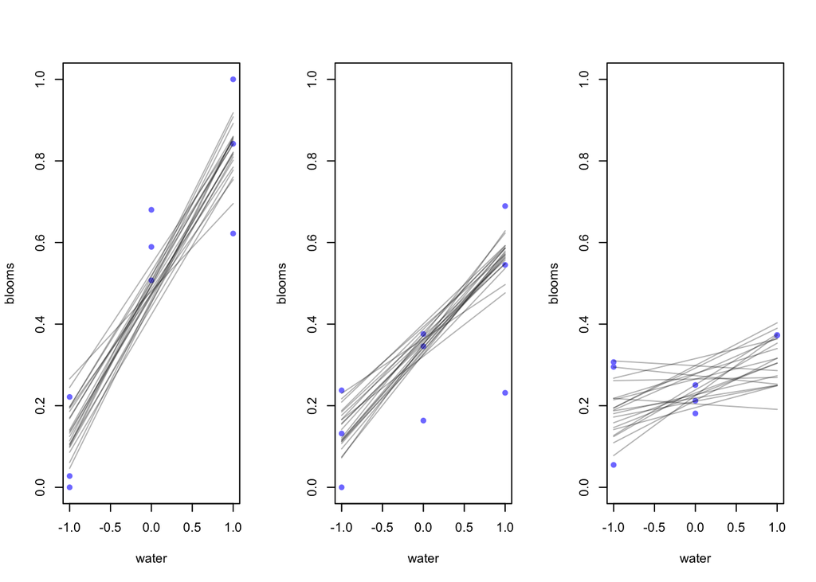

```r
par(mfrow=c(1, 3))
for (s in -1:1){
  mu = link(m8.5, data=data.frame(shade_cent=s,
                                  water_cent=-1:1))

  idx = which(d$shade_cent==s)
  plot(d$water_cent[idx], d$blooms_std[idx],
       xlim=c(-1, 1), ylim=c(0, 1),
       xlab="water", ylab="blooms",
       pch=16, col=rangi2)
  for (i in 1:20) lines(-1:1, mu[i,], col=col.alpha("black", 0.3))
}
```

We can see how as the shade goes from -1 to 0 to 1, how the number of blooms decreases even when there is normally enough water when there is little shade.